# Merging and batch correction

The goal of this small tutorial is to show how to merge and batch correct two datasets. Here we will use the integration and batch correction approach outlined in https://www.cell.com/cell/fulltext/S0092-8674(19)30559-8

Integration of single-cell sequencing datasets, for example across experimental batches, donors, or conditions, is often an important step in scRNA-seq workflows. Integrative analysis can help to match shared cell types and states across datasets, which can boost statistical power, and most importantly, facilitate accurate comparative analysis across datasets.

# Libraries

```r
library(Seurat)

set.seed(123)
```

## Read the data

We will use the following datasets for merging and integration.

- Donor 1: Peripheral blood mononuclear cells (PBMCs) from a healthy human male donor, aged 18-35 were obtained by 10x Genomics from Cellular Technologies Limited.
- Donor 3: Peripheral blood mononuclear cells (PBMCs) from a healthy human female donor, aged 36-50 were obtained by 10x Genomics from Cellular Technologies Limited.

Download and unzip Gene Expression - Feature / cell matrix (per sample) from donor 1 and donor 3 from: https://www.10xgenomics.com/datasets/5k_Human_Donor1_PBMC_3p_gem-x https://www.10xgenomics.com/datasets/5k_Human_Donor3_PBMC_3p_gem-x

```r
PBMC_donor1.data <- Read10X(data.dir = "/Users/miguel/Documents/scRNAseq course/2025/sample_filtered_feature_bc_matrix_Donor1/")
PBMC_donor3.data <- Read10X(data.dir = "/Users/miguel/Documents/scRNAseq course/2025/sample_filtered_feature_bc_matrix_Donor3/")

#PBMC_donor1.data <- Read10X(ADD_DATASET_PATH)
#PBMC_donor3.data <- Read10X(ADD_DATASET_PATH)


srat_donor1 <- CreateSeuratObject(counts = PBMC_donor1.data, project = "PBMC_d1")
srat_donor3 <- CreateSeuratObject(counts = PBMC_donor3.data, project = "PBMC_d3")
```

We can then merge the Seurat objects, storing all information in a single object for ease of use.

```r
srat_merge <- merge(srat_donor1,
              y = c(srat_donor3),
              add.cell.ids = c("PBMC_d1", "PBMC_d3"),
              project = "pbmc_all")
```

Mitochondrial RNA and plotting

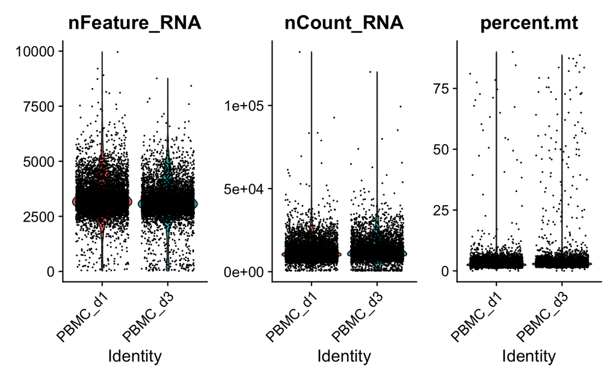

```r
srat_merge[["percent.mt"]] <- PercentageFeatureSet(srat_merge, pattern = "^MT-")

VlnPlot(srat_merge, features = c("nFeature_RNA", "nCount_RNA", "percent.mt"), ncol = 3, group.by = 'orig.ident')
```

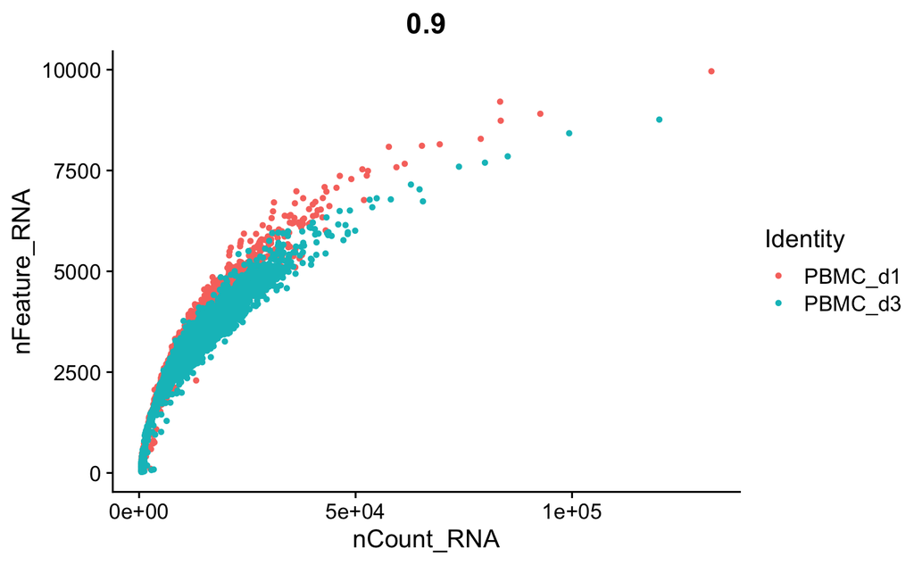

```r
FeatureScatter(srat_merge, feature1 = "nCount_RNA", feature2 = "nFeature_RNA", group.by = 'orig.ident')
```

Let’s stick to same filters for both, but it is better to filter each dataset independently.

```r
# define condition for filtering
cells_to_filter_merge <- rownames(subset(srat_merge, subset = nFeature_RNA > 1000 & nFeature_RNA < 10000 & nCount_RNA > 1000 & nCount_RNA < 50000 &  percent.mt < 10)@meta.data)
# add this information to the metadata
srat_merge$keep <- rownames(srat_merge@meta.data) %in% cells_to_filter_merge

srat_merge <- subset(srat_merge, subset = keep)
```

SCTransform, PCA and UMAP

```r
srat_merge <- SCTransform(srat_merge,
                    vars.to.regress = c("nCount_RNA", "percent.mt"),
                    variable.features.n = 5000) %>%
  RunPCA(assay = "SCT", npcs = 50) %>%
  RunUMAP(dims = 1:20)
```

```
Running SCTransform on assay: RNA
Running SCTransform on layer: counts.PBMC_d1
vst.flavor='v2' set. Using model with fixed slope and excluding poisson genes.
Variance stabilizing transformation of count matrix of size 23350 by 5613
Model formula is y ~ log_umi
Get Negative Binomial regression parameters per gene
Using 2000 genes, 5000 cells
Found 22 outliers - those will be ignored in fitting/regularization step

Second step: Get residuals using fitted parameters for 23350 genes
Computing corrected count matrix for 23350 genes
Wall clock passed: Time difference of 19.32171 secs
Determine variable features

Centering data matrix

Getting residuals for block 1(of 2) for PBMC_d1 dataset
Getting residuals for block 2(of 2) for PBMC_d1 dataset
Centering data matrix

Finished calculating residuals for PBMC_d1
Running SCTransform on layer: counts.PBMC_d3
vst.flavor='v2' set. Using model with fixed slope and excluding poisson genes.
Variance stabilizing transformation of count matrix of size 21151 by 4620
Model formula is y ~ log_umi
Get Negative Binomial regression parameters per gene
Using 2000 genes, 4620 cells
Found 2 outliers - those will be ignored in fitting/regularization step

Second step: Get residuals using fitted parameters for 21151 genes
Computing corrected count matrix for 21151 genes
Wall clock passed: Time difference of 15.26788 secs
Determine variable features

Centering data matrix

Set default assay to SCT
PC_ 1
Positive:  LYZ, PID1, ZEB2, DOCK4, S100A9, KYNU, VCAN, NEAT1, S100A8, CST3
       FNDC3B, RAB31, JARID2, THBS1, G0S2, PLXDC2, EPB41L3, DMXL2, IFI30, FCN1
```

[output cut: 18 more lines]

```
PC_ 4
Positive:  DOCK4, IGKC, TCF4, JARID2, FNDC3B, BANK1, MS4A1, SIPA1L1, PPARG, FCHSD2
       FNDC3A, NEAT1, ZEB1, IGHM, ZEB2, ZSWIM6, EBF1, VCAN, MAML2, KYNU
       COBLL1, ETV6, AFF3, LINC-PINT, SDC2, RALGPS2, ARHGAP24, ARID5B, PDE3B, PLEKHG1
Negative:  CST3, LYZ, IFI30, HLA-DRA, FTH1, HLA-DRB1, HLA-DPA1, FTL, GNLY, AIF1
       TYROBP, CD74, CCL5, CTSS, NKG7, LST1, S100A4, S100A9, CEBPD, IFITM3
       FCN1, PSAP, ACTB, SERPINA1, GPX1, FCGR3A, HLA-DPB1, FCER1G, HLA-DRB5, PFN1
PC_ 5
Positive:  S100A9, LYZ, S100A8, GNLY, VCAN, DOCK4, PID1, IGKC, CCL5, THBS1
       SERPINB2, NKG7, IGHM, BANK1, MS4A1, CCL4, PPARG, S100A12, CD79A, LUCAT1
       IGHD, SLC11A1, TLR2, ADAM28, G0S2, EREG, SLC16A10, ASPH, PLCB1, CYP1B1
Negative:  CST3, PAPSS2, LST1, SLC8A1, CDKN1C, LYN, AIF1, IFITM3, FCGR3A, DST
       IFI30, HLA-DPA1, COTL1, DAPK1, CTSS, RNF144B, GRK3, MGLL, CD86, PECAM1
       SERPINA1, CYRIA, PPP1R17, ENSG00000287682, NEAT1, ADAM10, TCF7L2, IRAK3, MTSS1, LINC00540
Using method 'umap'
```

Plot UMAP coloured by orig.ident

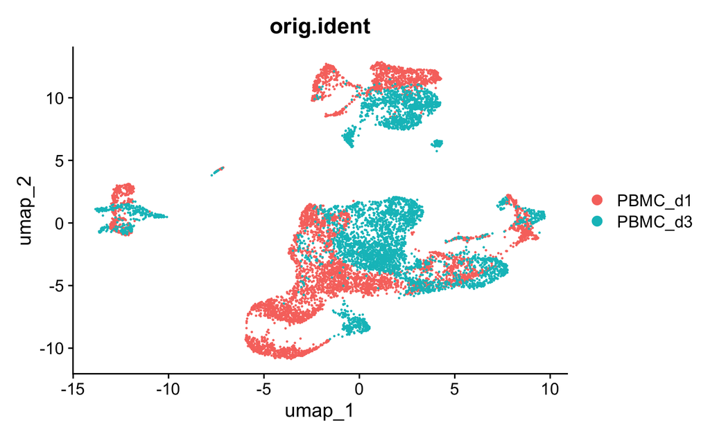

```r
DimPlot(srat_merge, reduction = 'umap', group.by = 'orig.ident')
```

Batch effect. But will it affect the results?

Let’s call clusters and see how the replicates are distributed in the them. If there are clusters with lots of one replicate and little of the other, this suggests that these clusters are driven by technical variation, which ought to be removed before analysis.

The clustering is done in two steps: generate a nearest-neighbours graph; call clusters (or “communities”) on this graph.

```r
srat_merge <- FindNeighbors(srat_merge, dims = 1:20)
srat_merge <- FindClusters(srat_merge, resolution = 0.1)
```

```
Modularity Optimizer version 1.3.0 by Ludo Waltman and Nees Jan van Eck

Number of nodes: 10233
Number of edges: 329328

Running Louvain algorithm...
```

```
Maximum modularity in 10 random starts: 0.9651
Number of communities: 10
Elapsed time: 0 seconds
```

```r
table(Cluster = srat_merge$SCT_snn_res.0.1, Batch = srat_merge$orig.ident)
```

```
       Batch
Cluster PBMC_d1 PBMC_d3
      0    2482     151
      1      19    2140
      2     574     650
      3      45    1045
      4     810       3
      5     376     331
      6     446     204
      7     504       3
      8     323      80
      9      34      13
```

By tabulating how many cells from each technical replicate fall in each cluster, we can see that some clusters have almost none of one replicate and lots of the other. If we proceeded with the uncorrected data in our downstream analysis, it might lead us to conclude that there are biological differences between our samples, which in this case we know should be very similar.

# Data integration

We can perform batch correction by using a method of data integration implemented in Seurat, which aims to bring cells of different samples closer together (while retaining as much of the biological variance as possible). Note, we used CCA but there are many (RPCA, Harmony, …) https://satijalab.org/seurat/articles/seurat5_integration

Firstly, we normalize and identify variable features for each dataset independently and make a list of the normalised Seurat objects

```r
# loop through the two samples
pbmc_list <- lapply(c(srat_donor1, srat_donor3), function(x) {
  x <- NormalizeData(x)
  x <- FindVariableFeatures(x, selection.method = "vst", nfeatures = 2000)
})
```

```
Normalizing layer: counts
Finding variable features for layer counts
Normalizing layer: counts
Finding variable features for layer counts
```

Then, we select features that are repeatedly variable across datasets which can be used for for integration. We are using a high value here (10000 features). You could try varying this to see if using fewer features affects the results.

```r
integration_features <- SelectIntegrationFeatures(object.list = pbmc_list, nfeatures=10000)
```

Perform the integration (this takes a while).

Here we left the Dimensional reduction to perform when finding anchors as the default Canonical Correlation Analysis (CCA), but there are more options. You can try the different integration methods and see how they compare.

```r
pbmc_anchors <- FindIntegrationAnchors(object.list = pbmc_list, anchor.features = integration_features)
```

```
  |                                                  | 0 % ~calculating
  |+++++++++++++++++++++++++                         | 50% ~00s
  |++++++++++++++++++++++++++++++++++++++++++++++++++| 100% elapsed=01s
```

```
Finding all pairwise anchors
```

```
  |                                                  | 0 % ~calculating
```

```
Running CCA
Merging objects
Finding neighborhoods
Finding anchors
    Found 11300 anchors
Filtering anchors
    Retained 8099 anchors
```

```
  |++++++++++++++++++++++++++++++++++++++++++++++++++| 100% elapsed=02m 01s
```

```r
pbmc_integrated <- IntegrateData(anchorset = pbmc_anchors)
```

```
Merging dataset 2 into 1
Extracting anchors for merged samples
Finding integration vectors
Finding integration vector weights
Integrating data
```

We now have an ‘integrated’ assay, as well as the standard ‘RNA’ assay.

```r
pbmc_integrated@assays
```

```
$RNA
Assay (v5) data with 38606 features for 10492 cells
Top 10 variable features:
 IL1B, CXCL8, IGKC, CXCL3, EBF1, HLA-DPA1, GNLY, HLA-DQA1, IFIT2,
CCL20
Layers:
 counts.PBMC_d1, counts.PBMC_d3, data.PBMC_d1, scale.data.PBMC_d1,
data.PBMC_d3, scale.data.PBMC_d3

$integrated
Assay data with 2639 features for 10492 cells
Top 10 variable features:
 IL1B, IFIT2, CCL4, GNLY, S100A9, CXCL8, EBF1, HLA-DPA1, SERPINB2,
BANK1
```

To proceed with the corrected data, we need to change our default assay. Note that the original unmodified data still resides in the ‘RNA’ assay.

```r
DefaultAssay(pbmc_integrated) <- "integrated"
```

Run the standard workflow for visualization and clustering:

```r
pbmc_integrated <- ScaleData(pbmc_integrated, verbose = FALSE)
pbmc_integrated <- RunPCA(pbmc_integrated, npcs = 50, verbose = FALSE)
pbmc_integrated <- RunUMAP(pbmc_integrated, reduction = "pca", dims = 1:20)
```

```
Using method 'umap'
```

Finally we are ready to visualise the corrected cells. The data look much better integrated, with a lot of overlapping between the different samples within clusters.

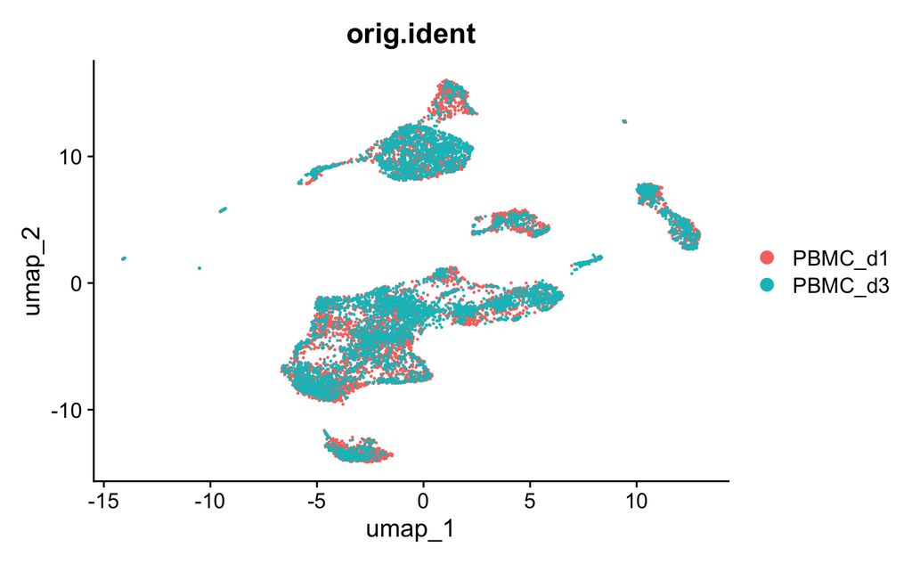

```r
DimPlot(pbmc_integrated, reduction = "umap", group.by = "orig.ident")
```

We can move on to identify clusters of corrected cells and see how the replicates are distributed:

```r
pbmc_integrated <- FindNeighbors(pbmc_integrated, dims = 1:20)
pbmc_integrated <- FindClusters(pbmc_integrated, resolution = 0.1)
```

```
Modularity Optimizer version 1.3.0 by Ludo Waltman and Nees Jan van Eck

Number of nodes: 10492
Number of edges: 394065

Running Louvain algorithm...
```

```
Maximum modularity in 10 random starts: 0.9708
Number of communities: 11
Elapsed time: 1 seconds
```

```r
table(Cluster = pbmc_integrated$integrated_snn_res.0.1, Batch = pbmc_integrated$orig.ident)
```

```
       Batch
Cluster PBMC_d1 PBMC_d3
     0     1863    1615
     1      782     992
     2      639     708
     3      628     455
     4      380     342
     5      527     192
     6      389     181
     7      328     101
     8       88      90
     9       52      93
     10      34      13
```